# 国家免疫规划疫苗儿童免疫程序表（2016版）

2017-08-11

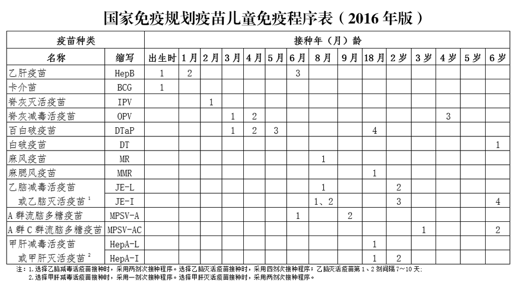

### **1.乙肝疫苗**

**注意事项**  
(1) 在医院分娩的新生儿由出生的医疗机构接种第1剂乙肝疫苗，由辖区预防接种单位完成后续剂次接种。未在医疗机构出生儿童由辖区预防接种单位全程接种乙肝疫苗。  
(2)HBsAg阳性或不详母亲所生新生儿应在出生后24小时内尽早接种第1剂乙肝疫苗；HBsAg阳性或不详母亲所生早产儿、低体重儿也应在出生后24小时内尽早接种第1剂乙肝疫苗，但在该早产儿或低体重儿满1月龄后，再按0、1、6月程序完成3剂次乙肝疫苗免疫。  
(3) HBsAg阴性的母亲所生新生儿也应在出生后24小时内接种第1剂乙肝疫苗，最迟应在出院前完成。  
(4)危重症新生儿，如极低出生体重儿、严重出生缺陷、重度窒息、呼吸窘迫综合征等，应在生命体征平稳后尽早接种第1剂乙肝疫苗。  
(5)HBsAg阳性母亲所生新生儿，可按医嘱在出生后接种第1剂乙肝疫苗的同时，在不同(肢体)部位肌肉注射100国际单位乙肝免疫球蛋白（HBIG）。  
(6)建议对HBsAg阳性母亲所生儿童接种第3剂乙肝疫苗1～2个月后进行HBsAg和抗-HBs检测。若发现HBsAg阴性、抗-HBs＜10mIU/ml，可按照0、1、6月免疫程序再接种3剂乙肝疫苗。  
**补种原则**  
a 若出生24小时内未及时接种，应尽早接种；  
b 对于未完成全程免疫程序者，需尽早补种，补齐未接种剂次即可；  
c 第1剂与第2剂间隔应≥28天，第2剂与第3剂间隔应≥60天。

### **2.卡介苗**

**注意事项**  
（1）未接种卡介苗的＜3月龄儿童可直接补种。  
（2）3月龄～3岁儿童对结核菌素纯蛋白衍生物（TB-PPD）或卡介菌蛋白衍生物（BCG-PPD）试验阴性者，应予补种。  
（3）≥4岁儿童不予补种。  
（4）已接种卡介苗的儿童，即使卡痕未形成也不再予以补种。

### **3.脊髓灰质炎疫苗**

**注意事项**  
（1）2016年5月1日之前使用三价OPV（tOPV），2016年5月1日开始使用二价OPV（bOPV），该日期之后，不得使用tOPV。  
（2）以下人群建议按照说明书全程使用IPV：原发性免疫缺陷、胸腺疾病、有症状的HIV感染或CD4T细胞计数低、正在接受化疗的恶性肿瘤、近期接受造血干细胞移植、正在使用具有免疫抑制或免疫调节作用的药物（例如大剂量全身皮质类固醇激素、烷化剂、抗代谢药物、TNF-α抑制剂、IL-1阻滞剂或其他免疫细胞靶向单克隆抗体治疗）、目前或近期曾接受免疫细胞靶向放射治疗。  
（3）如果儿童已按疫苗说明书接种过IPV或含脊灰疫苗成分的联合疫苗，可视为完成相应剂次的脊灰疫苗接种。  
**补种原则**  
（1）对于脊灰疫苗迟种、漏种儿童，补种相应剂次即可，无需重新开始全程接种。＜4岁儿童未达到3剂（含补充免疫等），应补种完成3剂；≥4岁儿童未达到4剂（含补充免疫等），应补种完成4剂。补种时两剂次脊灰疫苗之间间隔≥28天。  
（2）IPV疫苗纳入国家免疫规划以后，无论在补充免疫、查漏补种或者常规免疫中发现脊灰疫苗为0剂次的目标儿童，首剂接种IPV。  
（3）2016年5月1日后，对于仅有bOPV接种史（无IPV或tOPV接种史）的儿童，补种1剂IPV。  
（4）既往已有tOPV免疫史（无论剂次数）而无IPV免疫史的迟种、漏种儿童，用现行免疫规划用OPV补种即可，不再补种IPV。

### **4.百白破疫苗**

**补种原则**  
（1）3月龄～5岁未完成DTaP规定剂次的儿童，需补种未完成的剂次，前3剂每剂间隔≥28天，第4剂与第3剂间隔≥6个月。  
（2）≥6岁接种DTaP和白破疫苗累计＜3剂的儿童，用白破疫苗补齐3剂；第2剂与第1剂间隔1～2月，第3剂与第2剂间隔6～12个月。  
（3）根据补种时的年龄选择疫苗种类，3月龄～5岁使用DTaP，6～11岁使用吸附白喉破伤风联合疫苗（儿童用），≥12岁使用吸附白喉破伤风联合疫苗（成人及青少年用）。

### **5.麻风疫苗**

**注意事项**  
（1）满8月龄儿童应尽早接种MR。  
（2）如果接种时选择用MMR，可视为完成MR接种。  
（3）MR可与其他的国家免疫规划疫苗按照免疫程序或补种原则同时、不同部位接种。  
（4）如需接种多种疫苗但无法同时完成接种时，则优先接种MR疫苗，若未能与其他注射类减毒活疫苗同时接种，则需间隔≥28天。  
（5）注射免疫球蛋白者应间隔≥3个月接种MR，接种MR后2周内避免使用免疫球蛋白。  
（6）当针对麻疹疫情开展应急接种时，可根据疫情流行病学特征考虑对疫情波及范围内的6～7月龄儿童接种1剂MR，但不计入常规免疫剂次。  
**补种原则**  
（1）扩免前出生的≤14岁儿童，如果未完成2剂含麻疹成分疫苗接种，使用MR或MMR补齐。  
（2）扩免后出生的≤14岁适龄儿童，应至少接种2剂含麻疹成分疫苗、1剂含风疹成分疫苗和1剂含腮腺炎成分疫苗，对未完成上述接种剂次者，使用MR或MMR补齐。